# exploration

Amber Thomas

3/14/2019

## Intro

This is an exploration of songs that contain names (from a Kaggle corpus of 57k songs searching for over 3k names that have been used more than 5k times between the 1950’s and now).

## Packages

```r
library(tidyverse)
library(here)
library(data.table)
library(gender)
library(Rspotify)
library(sentimentr)
library(magrittr)
library(glue)
```

## Preparing data

Let’s start by just loading the data.

```r
nameData <- fread(here::here("processed_data", "songNames.csv"), data.table =FALSE)
```

## Exploration

How many songs (out of 40k) had a name in it?

```r
count <- nameData %>% distinct(artist, song) %>% summarise(count = n())
```

Ok, so there’s

| count |
| --- |
| 12142 |

(

| count |
| --- |
| 30.355 |

%) songs with names.

Let’s limit to just the ones that are “proper nouns” and filter out any where the sentence is just the name in parentheses or brackets.

```r
proper <- nameData %>%
  filter(upos == "PROPN") %>%
  mutate(sentence = gsub("(\\(|\\[).*(\\)|\\])", "", sentence)) %>%
  filter(sentence != "")
```

### Most Common Names

Ok, out of those, which are the most common?

```r
common <- proper %>%
  count(name, sort = TRUE)

common
```

| name | n |
| --- | --- |
| Baby | 2554 |
| Jesus | 2054 |
| Heaven | 999 |
| King | 580 |
| Johnny | 576 |
| Mary | 530 |
| John | 511 |
| America | 482 |
| May | 389 |
| Joe | 388 |

[output cut: 1543 more lines]

### By Artist

Which artists use the most names?

```r
byArtist <- proper %>%
  distinct(artist, song) %>%
  count(artist, sort = TRUE)

byArtist
```

| artist | n |
| --- | --- |
| Fabolous | 91 |
| David Allan Coe | 85 |
| Jimmy Buffett | 83 |
| Hillsong | 78 |
| Bob Dylan | 77 |
| Bruce Springsteen | 72 |
| Christmas Songs | 72 |
| Frank Zappa | 72 |
| John Mellencamp | 72 |
| Insane Clown Posse | 71 |

[output cut: 596 more lines]

Woah, some of these artists have a lot of songs with names! Let’s look at `Fabolous`.

```r
fab <- proper %>%
  filter(artist == "Fabolous") %>%
  distinct(song, .keep_all = TRUE) %>%
  count(name, sort = TRUE)

fab
```

| name | n |
| --- | --- |
| Brooklyn | 9 |
| Baby | 7 |
| Bentley | 4 |
| John | 4 |
| America | 2 |
| Andrew | 2 |
| Ben | 2 |
| Billy | 2 |
| Boston | 2 |
| Cali | 2 |

[output cut: 52 more lines]

Ok, so some of these are most likely references to places (i.e., `Brooklyn`, `America`) or things (`Bentley`). Let’s look at `John`.

```r
johnFab <- proper %>%
  filter(artist == "Fabolous" & name == "John")

johnFab$sentence
```

```
## [1] "And y'all wanna hear em go bang bang bang Like John Witherspoon, I'm watching em closely I know the snakes gonna slither soon"
## [2] "Keep honeys on their knees, scuffin' they shins I deal wit nothing but tens I be the club king wit diamonds shuffling your friends Chickens get keys, scuffing the Benz Cause they want to lock me down like I'm Puff in the pens Snatch any chink blond who feel my link long view "
## [3] "If I could say so myself, I came a long way Even though I feel like the same old John J."
## [4] "You can't mob him Unless its for a autograph I ought to laugh Like ha ha ha ha I'm in a Jay-Z edition Otto ma ha ha ha New Blue Yankee Rich Yung long John Red Monkey Jeans this shit from Hong Kong I'm long gone "
## [5] "I blame them horses when I turn that Porsche turby on  My engine gettin' his Kentucky derby on, Seats is brunette paint is dirty blond Speaking of dirty blond's Say hi to curvy Don Fergie John"
## [6] "And I gotta go Hold on, baby please, you can't leave now, no, John baby, please"
```

Well, that seems to check out. Let’s spot check someone from a different genre: `Jimmy Buffett`

```r
buff <- proper %>%
  filter(artist == "Jimmy Buffett") %>%
  distinct(song, .keep_all = TRUE) %>%
  count(name, sort = TRUE)

buff
```

| name | n |
| --- | --- |
| Jimmy | 8 |
| America | 3 |
| Jay | 3 |
| Alan | 2 |
| Baby | 2 |
| Bob | 2 |
| Boston | 2 |
| Carolina | 2 |
| Eve | 2 |
| Joe | 2 |

[output cut: 52 more lines]

He says his own name a lot. Let’s make sure that looks right:

```r
jimmyBuff <- proper %>%
  filter(artist == "Jimmy Buffett" & name == "Jimmy")

jimmyBuff$sentence
```

```
##  [1] "You can drink some beer down there Argue, laugh and cheer down there Pass another year down there Jimmy got caught smokin' a joint Out behind the bar, sittin' in his car And they took him to jail The tip jar paid his bail In 1984 Mick Jagger passed through town Bought the house a round Sign…
##  [2] "Jimmy Buffett"
##  [3] "Jimmy Buffett"
##  [4] "Another Saturday night By: Jimmy Buffett Another Saturday night and I ain't got nobody I've got some money cause I just got paid"
##  [5] "Jimmy Buffett, Russ Kunkel, Jay Oliver, Roger Guth, and Peter Mayer HE'S A MAN ON A MISSION WILD AS A RICOCHET PICTURE IF YOU CAN WHEN THE EVERGLADES RAN FROM THE GULF COAST TO BISCAYNE BAY HE'S GONNA GIVE IT BACK TO THE GATORS LOCK THE TOURISTS UP IN THEME PARKS AND ZOOS HE SAYS \\\"JOIN M…
##  [6] "Jimmy Buffett, Russ Kunkel, Jay Oliver, Roger Guth, and Peter Mayer THE RUMORS AND THE STORIES OF MY PAST I CAN'T DENY I'M NO ST."
##  [7] "Lyrics by Jimmy Buffett Music by Buffett, Kunkel, Guth, P. Mayer, J. Mayer I'm a cultural infidel, painting in the dark I'm a cultural infidel, singing in the park Socrates, hypothesis, the music of Mozart I'm a cultural infidel, coming from the heart Free thinkin', hoodwinkin', unblinkin' …
##  [8] "Jimmy Buffett Fun tickets in my pocket, visions in my brain Grand father always told me it I went down I might never come back again I studied the language tapes And"
##  [9] "When my friends told me hey Jimmy It must have been the hoodlum drink"
## [10] "In my brain sayin' \\\"Jimmy Buffett there's a great day a comin'\\\" 'Cause I was drunk I wasn't knee crawlin', slip slidin', Reggie Youngin' Commode huggin' drunk I was God's own drunk and a fearless man"
## [11] "Jimmy Buffett"
## [12] "Jimmy Buffett, Will Jennings, Michael Utley"
## [13] "At a moment like this, I can't help But wonder what would Jimmy Buffett do."
## [14] " It's five o'clock somewhere."
## [15] " Jimmy: What time zone am I on?"
## [16] "Jimmy: It's always on time for Margarita ville."
## [17] "Jimmy: You've been there haven't ya?"
## [18] "Jimmy: I've seen your boat there."
## [19] "Jimmy: Alright, that's good."
## [20] "Jimmy: Okay, well I just want to make sure you keep it between the navigational beacons."
## [21] "Jimmy: Alright, well it's five o'clock."
## [22] "Jimmy: Let's get out of here."
## [23] "Jimmy Buffett"
## [24] "Jimmy Buffett, Russ Kunkel, Jay Oliver, Roger Guth, and Peter Mayer Verse NORDSTROM WAS A SIMPLE MAN WHO HATCHED A NON-CONFORMIST PLAN TO SAVE HIS ASS EVERY NIGHT HE DANCED ALONE AND BLOTTED OUT THE MONOTONE THAT WAS HIS PAST HE PACKS HIS BAG OF MYSTERIES AND LEAVES THE LONELY MEMORIES WHER…
## [25] "He said I ate the last mango in Paris I took the last plane out of Saigon Took the first fast boat to China And Jimmy there's still so much to be done I had a third world girl in Buzios With a pistol in each hand She always kept me covered"
```

Ah, we’ve got a minor data issue where his name has been inserted into the lyrics to indicate that he is speaking. I’ll have to think about how to remove this.

Let’s check one more: `Cher`.

```r
cher <- proper %>%
  filter(artist == "Cher") %>%
  distinct(song, .keep_all = TRUE) %>%
  count(name, sort = TRUE)

cher
```

| name | n |
| --- | --- |
| Baby | 14 |
| Sonny | 3 |
| Bob | 2 |
| Dixie | 2 |
| Heaven | 2 |
| Jesus | 2 |
| Billy | 1 |
| Boston | 1 |
| Chastity | 1 |
| Columbus | 1 |

[output cut: 13 more lines]

How many of these names are the artists’ own name (either purposely in the data or a data-error?)

```r
own <- proper %>%
  mutate(own = str_detect(artist, regex(glue("\\b{name}([:space:]|\\n)"))))
ownName <- own %>%
  filter(own == TRUE)

notOwn <- own %>%
  filter(own == FALSE)
```

Alright, so that’s not too bad, only 794 or (2.2485274%) of songs conceivably have this error.

### Song with most names

Which songs say the same name the most times?

```r
most <- proper %>%
  group_by(artist, song, name) %>%
  summarise(count = n()) %>%
  ungroup() %>%
  arrange(desc(count))

head(most, n = 50)
```

| artist | song | name | count |
| --- | --- | --- | --- |
| Diana Ross | Mr. Lee | Lee | 49 |
| Beach Boys | Barabara Ann | Ann | 44 |
| Beach Boys | Barbara Ann | Ann | 44 |
| Avril Lavigne | Hello Kitty | Kitty | 43 |
| Adele | River Lea | Lea | 40 |
| Ian Hunter | Cleveland Rocks | Cleveland | 40 |
| Children | Billy Boy (version 2) | Billy | 39 |
| Frank Zappa | Dong Work For Yuda | John | 38 |
| Morrissey | Dagenham Dave | Dave | 37 |
| Arrogant Worms | Steel Drivin' Man | Mike | 34 |

[output cut: 40 more lines]

And which songs have the most different names?

```r
different <- proper %>%
  group_by(artist, song) %>%
  distinct(name) %>%
  summarise(count = n()) %>%
  arrange(desc(count))

head(different, n = 50)
```

| artist | song | count |
| --- | --- | --- |
| Dolly Parton | I Dreamed Of A Hillbilly Heaven | 39 |
| Billy Joel | We Didn't Start The Fire | 28 |
| Adam Sandler | Listenin' To The Radio | 27 |
| Adam Sandler | The Chanukah Song Pt. 3 | 26 |
| Nitty Gritty Dirt Band | Grand Ole Opry Song | 22 |
| Frank Zappa | Honey, Don't You Want A Man Like Me? | 17 |
| Rihanna | Vogue | 17 |
| Adam Sandler | Dancin' And Pantsin' | 16 |
| David Allan Coe | Free My Mind | 16 |
| Elton John | Give Peace A Chance | 16 |

[output cut: 40 more lines]

### Gendered Difference in Names

```r
findGender <- function(name){
  years <- c(1963, 2012)

  gender(name, years)
}

genderedNames <- map_dfr(common$name, findGender)

cleanGenderedNames <- genderedNames %>%
  mutate(gen = ifelse(proportion_male >= 0.6, "male",
                      ifelse(proportion_female >= 0.6, "female", "unknown")))

countGendered <- notOwn %>%
  count(name, sort = TRUE) %>%
  left_join(cleanGenderedNames) %>%
  select(c(name, n, gen)) %>%
  group_by(gen) %>%
  arrange(desc(n)) %>%
  mutate(rank = row_number()) %>%
  filter(rank <= 20)
countGendered
```

| name | n | gen | rank |
| --- | --- | --- | --- |
| Baby | 2554 | unknown | 1 |
| Jesus | 2054 | male | 1 |
| Heaven | 999 | female | 1 |
| King | 579 | male | 2 |
| Johnny | 562 | male | 3 |
| Mary | 528 | female | 2 |
| America | 482 | female | 3 |
| John | 438 | male | 4 |
| May | 389 | female | 4 |
| Joe | 388 | male | 5 |

[output cut: 50 more lines]

### Adding Sentiment Data

Anything interesting about the sentiment of a song with different names?

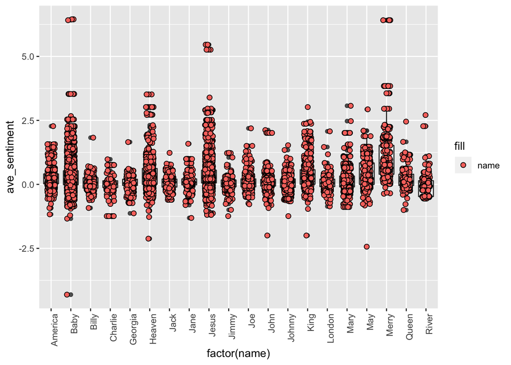

```r
distinctSongs <- notOwn %>%
  distinct(artist, song, .keep_all = TRUE)

sentiment <- distinctSongs %>%
  dplyr::mutate(dialogue_split = get_sentences(lyrics)) %$%
  sentiment_by(dialogue_split, list(artist, song))

sentimentByName <- notOwn %>%
  left_join(sentiment, by = c("artist", "song"))

sentimentGroup <- sentimentByName %>%
  group_by(name) %>%
  summarise(count = n(),
            avg = mean(ave_sentiment),
            stdev = sd(ave_sentiment)) %>%
  arrange(desc(count)) %>%
  filter(count >= 5)

namesToCheck <- head(sentimentGroup, n = 20) %$%
  name

limitedNames <- sentimentByName %>%
  filter(name %in% namesToCheck)


ggplot(limitedNames, aes(x = factor(name), y = ave_sentiment)) +
  geom_boxplot(alpha = 0.80) +
  geom_point(aes(fill = "name"), size = 2, shape = 21, position = position_jitterdodge())  +
  theme(axis.text.x = element_text(angle = 90, hjust = 1))
```

How about the songs with the highest sentiment?

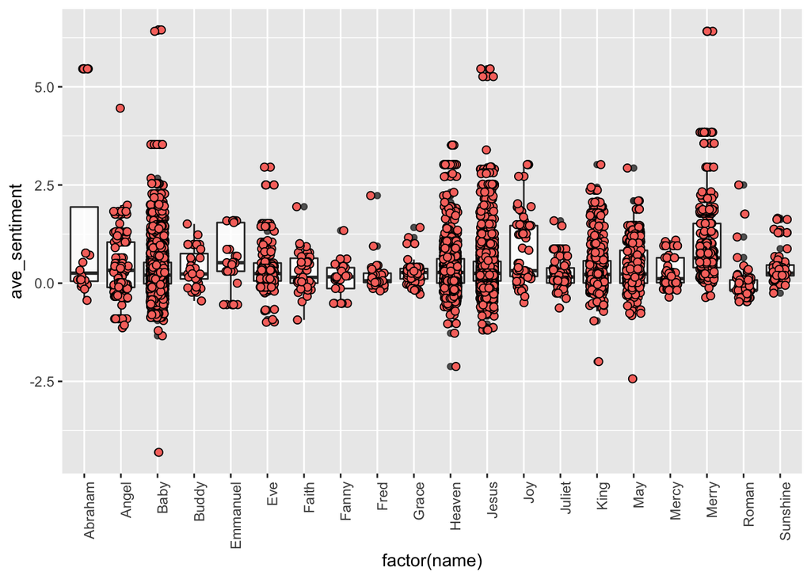

```r
highestNames <- sentimentByName %>%
  distinct(lyrics, .keep_all = TRUE) %>%
  group_by(name) %>%
  summarise(count = n(),
            avg = mean(ave_sentiment),
            stdev = sd(ave_sentiment)) %>%
  arrange(desc(avg)) %>%
  filter(count >= 10)

namesToCheck <- head(highestNames, n = 20) %$%
  name

limitedNames <- sentimentByName %>%
  filter(name %in% namesToCheck)


ggplot(limitedNames, aes(x = factor(name), y = ave_sentiment)) +
  geom_boxplot(alpha = 0.80) +
  geom_point(aes(fill = "name"), size = 2, shape = 21, position = position_jitterdodge()) + theme(legend.position="none") +
  theme(axis.text.x = element_text(angle = 90, hjust = 1))
```

Or the lowest sentiment

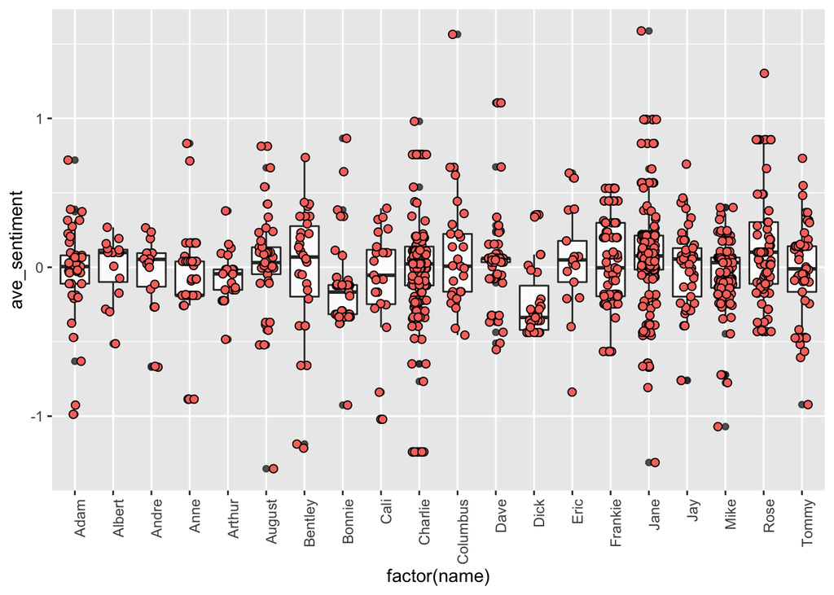

```r
lowestNames <- sentimentByName %>%
  distinct(lyrics, .keep_all = TRUE) %>%
  group_by(name) %>%
  summarise(count = n(),
            avg = mean(ave_sentiment),
            stdev = sd(ave_sentiment)) %>%
  arrange((avg)) %>%
  filter(count >= 10)

namesToCheck <- head(lowestNames, n = 20) %$%
  name

limitedNames <- sentimentByName %>%
  filter(name %in% namesToCheck)


ggplot(limitedNames, aes(x = factor(name), y = ave_sentiment)) +
  geom_boxplot(alpha = 0.80) +
  geom_point(aes(fill = "name"), size = 2, shape = 21, position = position_jitterdodge()) + theme(legend.position="none") +
  theme(axis.text.x = element_text(angle = 90, hjust = 1))
```

Or the name with the lowest variation in sentiment?

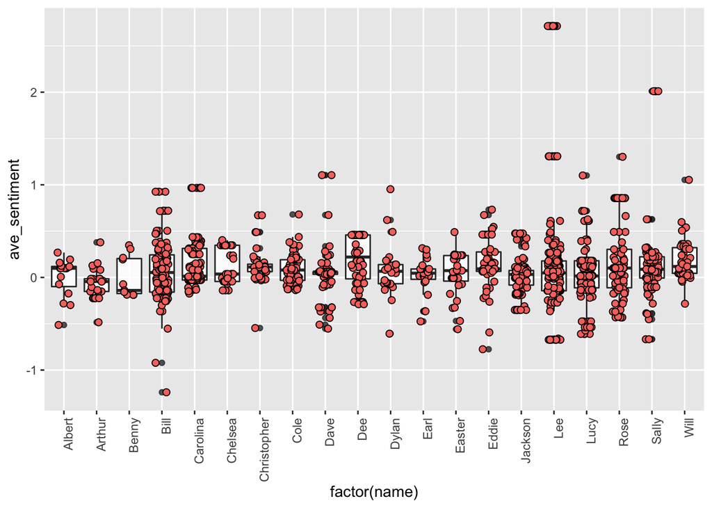

```r
lowestVar <- sentimentByName %>%
  distinct(lyrics, .keep_all = TRUE) %>%
  group_by(name) %>%
  summarise(count = n(),
            avg = mean(ave_sentiment),
            stdev = sd(ave_sentiment)) %>%
  arrange((stdev)) %>%
  filter(count >= 10)

namesToCheck <- head(lowestVar, n = 20) %$%
  name

limitedNames <- sentimentByName %>%
  filter(name %in% namesToCheck)


ggplot(limitedNames, aes(x = factor(name), y = ave_sentiment)) +
  geom_boxplot(alpha = 0.80) +
  geom_point(aes(fill = "name"), size = 2, shape = 21, position = position_jitterdodge()) + theme(legend.position="none") +
  theme(axis.text.x = element_text(angle = 90, hjust = 1))
```

## Other Possibilities

- Generate playlist of songs for each name
- Look at change over time
- Look at names by genre